2022-06-15

# Overview

Attempt to better characerize dissertation proposal

# Intro

Spoken words create audio signals that are processed by the brain in real time. As the word unfolds, a cohort of possible resolutions are activated..

An important part of this process involves not only correctly identifying the word but also eliminating competitors. For example, we might consider a discrete unfolding of a word such as “elephant as”el-e-phant”. At the onset of “el”, a listener may activate a cohort of words such as “elephant”, “electricity”, or “elder”, all of which may be considered competitors. With the subsequent “el-e”, “elephant” and “electricity” remain active competitors, while “elder” is eliminated. Such is a rough description of this process, continuing until the ambiguity is resolved and a single word remains.

The degree to which a particular word has been identified is known as its activation, typically scaled to values between 0 and 1.

Our interest is in measuring the degree of activation. relative to competitors. One method of doing so is situated in the context of the Visual World Paradigm (VWP) in which participants listen to a spoken word and also eyetracking. Come back to this. Our goal here in this overview is to demonstrate current methods and introduce a new one.

The Visual World Paradigm (VWP) simulates this scenario by placing participants in a “visual world” environment. A word is spoken, and participants are asked to identify in this environment an object corresponding to the spoken word. Though activation is a latent cognitive process, a camera is used to follow the trajectory of the participants’ eyes as they fixate on different objects before selecting the correct one.

Everything covered within considered in the context of VWP in which there is often a desire to identify quantitative differences between study groups re. eyetracking behavior, “activation” of word, latent processes, etc.,

In contrast to current methods commonly utilized in VWP which rely on an aggregation of trials to produce a curve indicating the proportion of trials in which a participant is fixated on a particular point at a particular time, we instead use saccades as our observed data, treating them as observations sampled from a latent cognitive process. In particular, although we are limited to observable mechanics of eye movement, it is this latent process of “activation” in which we are interested in identifying.

Through this document, we will briefly consider the motivation for this curve, simulated scenarios for a variety of conditions, and the implications for its use in the VWP.

# Eyetracking data

As the latent “activation” of a target is not measured, we instead rely on what can be observed directly from eyetracking data. There are a number of readily enumerated characteristics that can be considered such as

- frequency of saccade
- duration of fixation
- repeated fixations to target
- response time in trial
- searching patterns

To define our terms, a *saccade* represents the physical movement of the eye, typically lasting between 20-200ms.

# Main Idea

As the latent “activation” of a target is not measured, we instead rely on what can be observed directly from eyetracking data. There are a number of readily enumerated characteristics that can be considered such as

- frequency of saccade
- duration of fixation
- repeated fixations to target
- response time in trial
- searching patterns

What we will focus on here is a curve representing the probability, over time, of a subject initiating a saccade and fixating on a particular object. While this (usually parametric) curve, $f_{\theta}(t)$ is functionally the data-generating mechanism for saccade fixation, we more closely identify it as a proxy measure of the underlying cognitive state without placing undue emphasis on the ocular mechanics themselves. In other words, letting $y_t$ represent the outcome of a saccade fixating on a particular target at time $t$, we have

$$y_t \sim Bern(f_{\theta}(t)).$$
where $y_t = 1$ indicates a saccade at time $t$ fixated on a target object

### A note on nomenclature

With regards to naming this curve, we are in a bit of a gray area: calling it an “activation” curve obscures the fact that this is not a direct measure of this otherwise latent process; calling it a “saccade” curve appears to place more emphasis on the ocular mechanics. For now, we will refer to it as a saccade curve, as it is understood literally to be the curve generating saccade data, though we actively remain open to other suggestions.

The four parameter logistic curve, identified as

$$f(t|\theta) = \frac{h-b}{1 + \exp\left(4 \cdot \frac{s}{h-b}(xo - t)
\right)} +b,$$
if often used to describe the trajectory of probability of a subject launching a saccade and fixating on the target location. As the plot below illustrates in an example case, a subject with the depicted fixation curve may initiate a saccade ending at time $t = 970$, with a probability of $p = 0.5$ of the subsequent fixation resting on target:

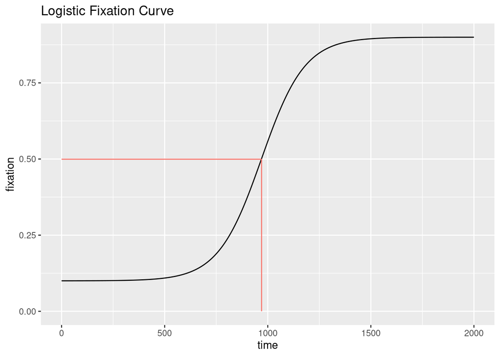

As saccade data is easily gathered from available eyetracking data, we are, in principle, able to collect samples directly from this curve. This goal is, however, complicated by “oculomotor delay”, the phenomenon in which the cognitive decision to launch a saccade and choose its subsequent target occurs some period of time before the movement itself.

In other words, an observed saccade at $t_j$ is likely a sample from the fixation curve $f_{\theta}(t)$ at some point prior to $t_j$. The degree to which this delay occurs, as well as the between and within subject variability is a matter of active investigation. Most generally, we may consider an observation $y_j$ at time $t_j$ to be

$$y_j \sim Bern \large[f_{\theta}(t_j - \rho(t_j)) \large]$$
where $\rho(t)$ represents oculomotor delay. As written, we may consider circumstances in which

1. $\rho(t)$ is a constant function (including 0)
2. $\rho(t)$ is a random variable, independent of the value of $t_j$
3. $\rho(t)$ is a random variable, dependent on $t_j$ and possibly other aspects of the trial

We will consider a variety of scenarios for oculomotor delay and the subsequent impacts on the recovery of the underlying fixation curve from the observed data

## Simulation

We begin with the implicit assumption that there is an underlying activation curve that may be described parametrically. The following simulations will generate data according to three scenarios:

1. A situation in which the occulomotor delay is known
2. A situation in which the occulomotor delay is unknown, but of a fixed quantity
3. A situation in which the occulomotor delay is an unknown random variable, independent of time

Each simulation will be conducted with $N = 300$ trials, sampled from the same data generating function for each, with the attempted recovery of the generating curve done using the `bdots` pacakge.

### Known delay

In the case in which the occulomotor delay is known, an unbiased recovery of the data generating curve is not an issue – we simply horizontally shift each observed saccade by it’s known occulmotor delay.

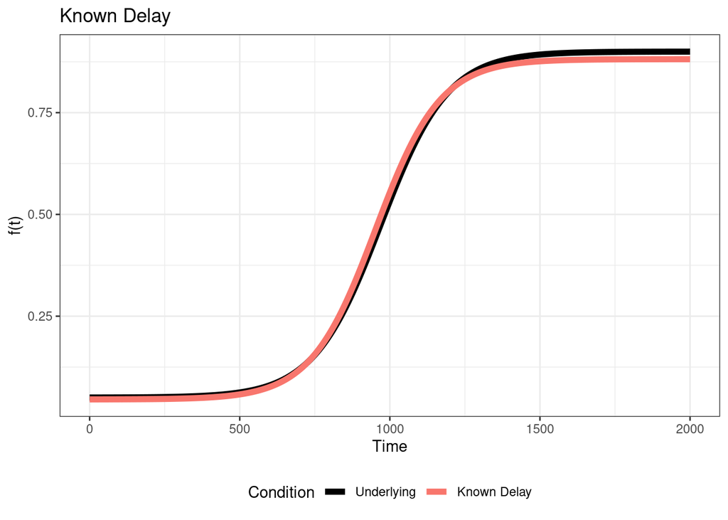

### Unknown fixed delay

The simulation was conducted using a fixed occulomotor delay of $\rho = 200ms$. Although the resulting recovered curve is biased, this bias simply results in a horizontal shift, $g(t) = f(t - \rho)$. This is especially relevant in a situation in which we are interested in comparing the data generating curve between two groups.

For example, one method of analyzing VWP data (which inspired the `bdots` package) was to determine on which intervals $I = \cup_{k} I_k$ two data generating curves were statistically different. Suppose, for simplicity, that there is an interval $I = [t_1, t_2]$ on which the difference between two curves, $f(t | \theta_1) - f(t|\theta_2)$, is statistically significant. Given that we observe $g_i(t) = f(t - \rho | \theta_i)$, we would simply find that a significant difference occurs at $I + \{\rho\} = [t_1 + \rho, t_2 + \rho]$, a horizontal shift resulting from the occulomotor delay.

In other words, the size of the interval would remain the same, and the relative differences between curves would be preserved under a horizontal shift.

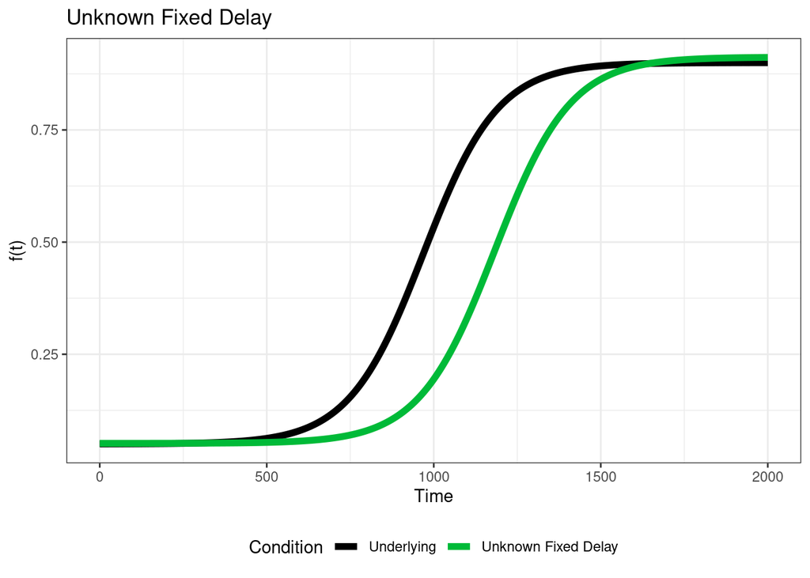

### Unknown random delay

The final scenario for consideration involves a situation is which the occulomotor delay is unknown and random. Here, the bias will not involve a simple horizontal shift, and the shape of the curve itself may be different between the one generating the data and the one observed.

We will interogate a number of potential methods for dealing with this issue, though we do feel confident that, even with this known bias, our proposed method will still be preferable to existing ones.

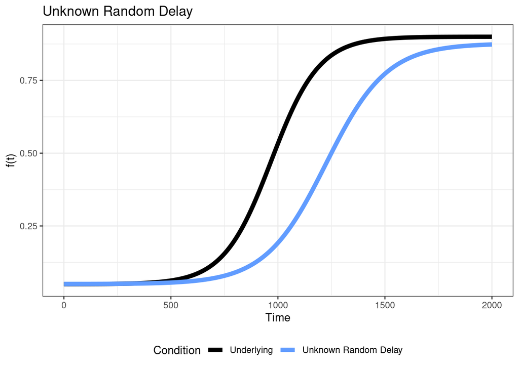

### Together

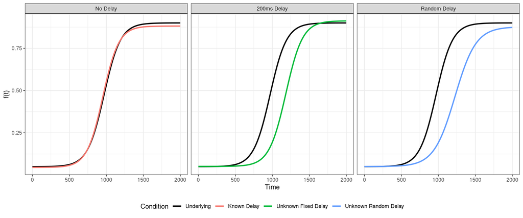

## Concluding Remarks

With regards to the curve described, there are a number of avenues seemingly worthy of investigation. The most pressing of these appears to be methods to minimize the amount of bias present in scenario three, which presents the largest obstacle in the functional recovery of the data generating mechanism. Of special note here is the fact that the particular intervals in which this bias occurs can have a large effect on the overall bias, over and above that introduced by the occulomotor delay.